# Practical Machine Learning Course Project

Jason McKenna

September 21, 2017

## R Markdown

1. Background (from assignment)

Using devices such as Jawbone Up, Nike FuelBand, and Fitbit it is now possible to collect a large amount of data about personal activity relatively inexpensively. These type of devices are part of the quantified self movement – a group of enthusiasts who take measurements about themselves regularly to improve their health, to find patterns in their behavior, or because they are tech geeks. One thing that people regularly do is quantify how much of a particular activity they do, but they rarely quantify how well they do it. In this project, your goal will be to use data from accelerometers on the belt, forearm, arm, and dumbell of 6 participants. They were asked to perform barbell lifts correctly and incorrectly in 5 different ways. More information is available from the website here: http://groupware.les.inf.puc-rio.br/har (see the section on the Weight Lifting Exercise Dataset).

2. Data (from assignment)

The training data for this project are available here:

https://d396qusza40orc.cloudfront.net/predmachlearn/pml-training.csv

The test data are available here:

https://d396qusza40orc.cloudfront.net/predmachlearn/pml-testing.csv

The data for this project come from this source: http://groupware.les.inf.puc-rio.br/har and can be cited as:

Velloso, E.; Bulling, A.; Gellersen, H.; Ugulino, W.; Fuks, H. Qualitative Activity Recognition of Weight Lifting Exercises. Proceedings of 4th International Conference in Cooperation with SIGCHI (Augmented Human ’13) . Stuttgart, Germany: ACM SIGCHI, 2013.

3. Data Structure Exploration & Cleaning

We first load the libraries we shall require:

```r
library(caret)
library(rattle)
```

```r
library(ggplot2)
library(randomForest)
```

We now examine the raw data and determine what pre-processing is required (if any):

```
## 'data.frame':    19622 obs. of  160 variables:
##  $ X                       : int  1 2 3 4 5 6 7 8 9 10 ...
##  $ user_name               : Factor w/ 6 levels "adelmo","carlitos",..: 2 2 2 2 2 2 2 2 2 2 ...
##  $ raw_timestamp_part_1    : int  1323084231 1323084231 1323084231 1323084232 1323084232 1323084232 1323084232 1323084232 1323084232 1323084232 ...
##  $ raw_timestamp_part_2    : int  788290 808298 820366 120339 196328 304277 368296 440390 484323 484434 ...
##  $ cvtd_timestamp          : Factor w/ 20 levels "02/12/2011 13:32",..: 9 9 9 9 9 9 9 9 9 9 ...
##  $ new_window              : Factor w/ 2 levels "no","yes": 1 1 1 1 1 1 1 1 1 1 ...
##  $ num_window              : int  11 11 11 12 12 12 12 12 12 12 ...
##  $ roll_belt               : num  1.41 1.41 1.42 1.48 1.48 1.45 1.42 1.42 1.43 1.45 ...
##  $ pitch_belt              : num  8.07 8.07 8.07 8.05 8.07 8.06 8.09 8.13 8.16 8.17 ...
##  $ yaw_belt                : num  -94.4 -94.4 -94.4 -94.4 -94.4 -94.4 -94.4 -94.4 -94.4 -94.4 ...
##  $ total_accel_belt        : int  3 3 3 3 3 3 3 3 3 3 ...
##  $ kurtosis_roll_belt      : Factor w/ 396 levels "-0.016850","-0.021024",..: NA NA NA NA NA NA NA NA NA NA ...
##  $ kurtosis_picth_belt     : Factor w/ 316 levels "-0.021887","-0.060755",..: NA NA NA NA NA NA NA NA NA NA ...
##  $ kurtosis_yaw_belt       : Factor w/ 1 level "#DIV/0!": NA NA NA NA NA NA NA NA NA NA ...
```

[output cut: 86 more lines]

```
## 'data.frame':    20 obs. of  160 variables:
##  $ X                       : int  1 2 3 4 5 6 7 8 9 10 ...
##  $ user_name               : Factor w/ 6 levels "adelmo","carlitos",..: 6 5 5 1 4 5 5 5 2 3 ...
##  $ raw_timestamp_part_1    : int  1323095002 1322673067 1322673075 1322832789 1322489635 1322673149 1322673128 1322673076 1323084240 1322837822 ...
##  $ raw_timestamp_part_2    : int  868349 778725 342967 560311 814776 510661 766645 54671 916313 384285 ...
##  $ cvtd_timestamp          : Factor w/ 11 levels "02/12/2011 13:33",..: 5 10 10 1 6 11 11 10 3 2 ...
##  $ new_window              : Factor w/ 1 level "no": 1 1 1 1 1 1 1 1 1 1 ...
##  $ num_window              : int  74 431 439 194 235 504 485 440 323 664 ...
##  $ roll_belt               : num  123 1.02 0.87 125 1.35 -5.92 1.2 0.43 0.93 114 ...
##  $ pitch_belt              : num  27 4.87 1.82 -41.6 3.33 1.59 4.44 4.15 6.72 22.4 ...
##  $ yaw_belt                : num  -4.75 -88.9 -88.5 162 -88.6 -87.7 -87.3 -88.5 -93.7 -13.1 ...
##  $ total_accel_belt        : int  20 4 5 17 3 4 4 4 4 18 ...
##  $ kurtosis_roll_belt      : logi  NA NA NA NA NA NA ...
##  $ kurtosis_picth_belt     : logi  NA NA NA NA NA NA ...
##  $ kurtosis_yaw_belt       : logi  NA NA NA NA NA NA ...
```

[output cut: 86 more lines]

The training data has 19,622 observations and 160 variables, whereas the testing data contains only 20 observations across the 160 variables. We are seeking to predict the outcome of the variable “classe” using as many of the predictors as necessary. “classe” is factor variable with 5 values (A,B,C,D,E):

```r
unique(training$classe)
```

```
## [1] A B C D E
## Levels: A B C D E
```

Its clear the data sets contain significant gaps. Prior knowledge of data analysis helps us quickly check for bias in classe by the user as well as date/time:

```r
table(training$classe, training$user_name, useNA = "ifany")
```

```
##
##     adelmo carlitos charles eurico jeremy pedro
##   A   1165      834     899    865   1177   640
##   B    776      690     745    592    489   505
##   C    750      493     539    489    652   499
##   D    515      486     642    582    522   469
##   E    686      609     711    542    562   497
```

```r
#
table(training$classe, training$cvtd_timestamp, useNA = "ifany")
```

```
##
##     02/12/2011 13:32 02/12/2011 13:33 02/12/2011 13:34 02/12/2011 13:35
##   A              177              988                0                0
##   B                0              333              443                0
##   C                0                0              750                0
##   D                0                0              182              333
##   E                0                0                0              686
##
##     02/12/2011 14:56 02/12/2011 14:57 02/12/2011 14:58 02/12/2011 14:59
##   A              235              664                0                0
##   B                0              716               29                0
##   C                0                0              539                0
##   D                0                0              642                0
##   E                0                0              154              557
##
##     05/12/2011 11:23 05/12/2011 11:24 05/12/2011 11:25 05/12/2011 14:22
##   A              190              644                0              267
##   B                0              690                0                0
##   C                0              163              330                0
##   D                0                0              486                0
##   E                0                0              609                0
##
##     05/12/2011 14:23 05/12/2011 14:24 28/11/2011 14:13 28/11/2011 14:14
##   A              373                0              833               32
##   B              505                0                0              592
##   C              492                7                0              489
##   D                0              469                0              385
##   E                0              497                0                0
##
##     28/11/2011 14:15 30/11/2011 17:10 30/11/2011 17:11 30/11/2011 17:12
##   A                0              869              308                0
##   B                0                0              489                0
##   C                0                0              643                9
##   D              197                0                0              522
##   E              542                0                0              562
```

Failing to observe any obvious bias we next delete the predictors within the training and testing data frames set that contain any missing values and are not required for predicting outcomes:

```r
training <- training[, colSums(is.na(training)) == 0]
testing <- testing[, colSums(is.na(testing)) == 0]
#
trainData <- training[, -c(1:7)]
testData <- testing[, -c(1:7)]
```

The pre-processed training and testing data now both have 53 columns (52 predictors and 1 outcome). The training and testing have 19,622 and 20 observations, respectively:

```r
dim(trainData)
```

```
## [1] 19622    53
```

```r
dim(testData)
```

```
## [1] 20 53
```

In order to obtain out-of-sample errors, we split the cleaned training set into a training dataset (train = 0.70), and a validation dataset (vali = 0.30) to compute the out-of-sample errors.

```r
set.seed(2112) #for all you RUSH fans!
inTrain <- createDataPartition(trainData$classe, p = 0.7, list = FALSE)
train <- trainData[inTrain, ]
valid <- trainData[-inTrain, ]
```

4. Outcome Prediction: Classification and Regression Trees

We will use two prediction methods to classify the “classe” outcome, and determine the most robust method: Classification and Regression Trees (“cart”) and random forests “rf (in the next section).

When using Classification and Regression Trees its a good idea to use k-fold cross validation with k-folds of 5 and 10. We also do not use any transformations on any predictors:

```r
control <- trainControl(method = "cv", number = 5)
fit_rpart <- train(classe ~ ., data = train, method = "rpart",
                   trControl = control)
print(fit_rpart, digits = 4)
```

```
## CART
##
## 13737 samples
##    52 predictor
##     5 classes: 'A', 'B', 'C', 'D', 'E'
##
## No pre-processing
## Resampling: Cross-Validated (5 fold)
## Summary of sample sizes: 10990, 10991, 10989, 10989, 10989
## Resampling results across tuning parameters:
##
##   cp       Accuracy  Kappa
##   0.03408  0.5031    0.35122
##   0.05995  0.4421    0.25219
##   0.11596  0.3334    0.07471
##
## Accuracy was used to select the optimal model using  the largest value.
## The final value used for the model was cp = 0.03408.
```

```r
#
control <- trainControl(method = "cv", number = 10)
fit_rpart <- train(classe ~ ., data = train, method = "rpart",
                   trControl = control)
print(fit_rpart, digits = 4)
```

```
## CART
##
## 13737 samples
##    52 predictor
##     5 classes: 'A', 'B', 'C', 'D', 'E'
##
## No pre-processing
## Resampling: Cross-Validated (10 fold)
## Summary of sample sizes: 12363, 12364, 12364, 12363, 12362, 12364, ...
## Resampling results across tuning parameters:
##
##   cp       Accuracy  Kappa
##   0.03408  0.5001    0.34709
##   0.05995  0.4543    0.27305
##   0.11596  0.3408    0.08592
##
## Accuracy was used to select the optimal model using  the largest value.
## The final value used for the model was cp = 0.03408.
```

Using 10-fold cross validation results in almost identical cp, accuracy, and Kappa when using 5, so we use k0fold = 5 for compuational efficiency. Plotting the results we observe that our tree fails to predict any “D” outcomes which seems suspicious.

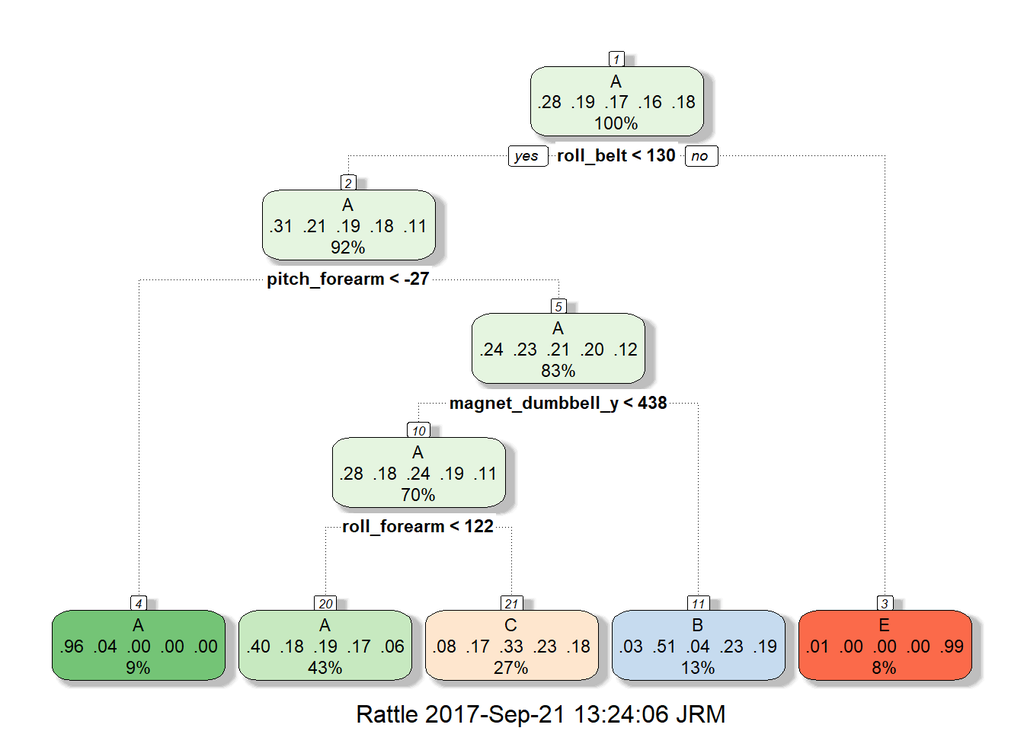

We now predict the outcome using our withheld validation set:

```r
predict_rpart <- predict(fit_rpart, valid)
confuse_rpart <- confusionMatrix(valid$classe, predict_rpart)
confuse_rpart
```

```
## Confusion Matrix and Statistics
##
##           Reference
## Prediction    A    B    C    D    E
##          A 1539   27  105    0    3
##          B  494  368  277    0    0
##          C  475   29  522    0    0
##          D  425  174  365    0    0
##          E  150  156  296    0  480
##
## Overall Statistics
##
##                Accuracy : 0.4943
##                  95% CI : (0.4815, 0.5072)
##     No Information Rate : 0.5239
##     P-Value [Acc > NIR] : 1
##
##                   Kappa : 0.3387
##  Mcnemar's Test P-Value : NA
##
## Statistics by Class:
##
##                      Class: A Class: B Class: C Class: D Class: E
## Sensitivity            0.4992  0.48806   0.3335       NA  0.99379
## Specificity            0.9518  0.84974   0.8833   0.8362  0.88856
## Pos Pred Value         0.9194  0.32309   0.5088       NA  0.44362
## Neg Pred Value         0.6333  0.91867   0.7853       NA  0.99938
## Prevalence             0.5239  0.12812   0.2659   0.0000  0.08207
## Detection Rate         0.2615  0.06253   0.0887   0.0000  0.08156
## Detection Prevalence   0.2845  0.19354   0.1743   0.1638  0.18386
## Balanced Accuracy      0.7255  0.66890   0.6084       NA  0.94117
```

```r
accuracy_rpart <- confuse_rpart$overall[1]
writeLines(c("\nCART Accuracy:", as.character(format(accuracy_rpart, nsmall = 4))))
```

```
##
## CART Accuracy:
## 0.4943076
```

Our predicted accuracy using the validation dataset is about 0.4943, so the out-of-sample error rate is about 0.5057 which is unacceptable.

We next try the Random Forest method for predicting the “classe” outcome.

5. Outcome Prediction: Random Forest

We use the training data from the “cart” anaylsis above, and after considerable computtional expnse obtain:

```r
control <- trainControl(method = "cv", number = 5)
fit_rf <- train(classe ~ ., data = train, method = "rf",
                trControl = control)
print(fit_rf, digits = 4)
```

```
## Random Forest
##
## 13737 samples
##    52 predictor
##     5 classes: 'A', 'B', 'C', 'D', 'E'
##
## No pre-processing
## Resampling: Cross-Validated (5 fold)
## Summary of sample sizes: 10990, 10989, 10988, 10991, 10990
## Resampling results across tuning parameters:
##
##   mtry  Accuracy  Kappa
##    2    0.9910    0.9887
##   27    0.9908    0.9884
##   52    0.9819    0.9772
##
## Accuracy was used to select the optimal model using  the largest value.
## The final value used for the model was mtry = 2.
```

Examinig our “rf” final model fit shows a much more robust classification for “rf” than “cart”:

```r
print(fit_rf$finalModel, digits = 4)
```

```
##
## Call:
##  randomForest(x = x, y = y, mtry = param$mtry)
##                Type of random forest: classification
##                      Number of trees: 500
## No. of variables tried at each split: 2
##
##         OOB estimate of  error rate: 0.68%
## Confusion matrix:
##      A    B    C    D    E  class.error
## A 3905    1    0    0    0 0.0002560164
## B   12 2638    8    0    0 0.0075244545
## C    0   22 2372    2    0 0.0100166945
## D    0    0   41 2209    2 0.0190941385
## E    0    0    0    5 2520 0.0019801980
```

We now predict the outcomes using “rf” on our validation set:

```r
predict_rf <- predict(fit_rf, valid)
confuse_rf <- confusionMatrix(valid$classe, predict_rf)
confuse_rf
```

```
## Confusion Matrix and Statistics
##
##           Reference
## Prediction    A    B    C    D    E
##          A 1674    0    0    0    0
##          B    5 1128    6    0    0
##          C    0    9 1017    0    0
##          D    0    0   16  948    0
##          E    0    0    0    1 1081
##
## Overall Statistics
##
##                Accuracy : 0.9937
##                  95% CI : (0.9913, 0.9956)
##     No Information Rate : 0.2853
##     P-Value [Acc > NIR] : < 2.2e-16
##
##                   Kappa : 0.992
##  Mcnemar's Test P-Value : NA
##
## Statistics by Class:
##
##                      Class: A Class: B Class: C Class: D Class: E
## Sensitivity            0.9970   0.9921   0.9788   0.9989   1.0000
## Specificity            1.0000   0.9977   0.9981   0.9968   0.9998
## Pos Pred Value         1.0000   0.9903   0.9912   0.9834   0.9991
## Neg Pred Value         0.9988   0.9981   0.9955   0.9998   1.0000
## Prevalence             0.2853   0.1932   0.1766   0.1613   0.1837
## Detection Rate         0.2845   0.1917   0.1728   0.1611   0.1837
## Detection Prevalence   0.2845   0.1935   0.1743   0.1638   0.1839
## Balanced Accuracy      0.9985   0.9949   0.9885   0.9979   0.9999
```

```r
accuracy_rf <- confuse_rf$overall[1]
writeLines(c("\nRF Accuracy:", as.character(format(accuracy_rf, nsmall = 4))))
```

```
##
## RF Accuracy:
## 0.9937128
```

6. Predictions with Test Data using the Random Forrest Method

We now use the “rf” method to predict the outcome variable “classe”" for the testing set:

```r
yy<-predict(fit_rf, testData)
yy
```

```
##  [1] B A B A A E D B A A B C B A E E A B B B
## Levels: A B C D E
```

7. Conclusion

Random Forest is clearly a superior predictor of desired outcomes. Classification and Regression Trees may fail in this example due to the fact that many predictors are highly correlated (this could be verified with Principle Component Analysis). For example, since Random Forests selects a smaller set of the predictors at each calculated split and decorrelates the resulting trees, it is inheritly more accurate.

Random Forests is not without issues, however, as the algorithm may sometimes be difficult to interpret, and is very computationaly inefficient.